# Sales Performance Analysis

**Author:** Scandal Murty  
**Date:** April 2026

## Overview

This project analyzes retail transaction data from a UK-based online retailer. The dataset contains over 545,000 transactions spanning multiple countries, customers, and product categories.

**Business Questions Answered:**

- Which countries generate the most revenue?
- What product categories drive the most sales?
- Who are the top customers by revenue?
- What are the top-selling products?
- How does revenue trend over time?

**Data Sources:**

- `TransactionsHistory.xlsx` — 545,592 transaction records (Invoice, StockCode, Quantity, Price, Customer_ID, Invoice_time)
- `CustomerMD.csv` — Customer ID to Country mapping
- `ProductMD.csv` — StockCode to Description, Category, Subcategory mapping

## 1. Setup & Data Loading

```python
import pandas as pd
import matplotlib.pyplot as plt
import matplotlib.ticker as mticker
import seaborn as sns
import warnings
warnings.filterwarnings('ignore')

# Set global plot style
sns.set_theme(style='darkgrid')
plt.rcParams['figure.figsize'] = (12, 5)
plt.rcParams['axes.titlesize'] = 14
plt.rcParams['axes.titleweight'] = 'bold'

# File paths
BASE = '/Users/deanm/Library/CloudStorage/GoogleDrive-scandalmurty@gmail.com/My Drive/Educational/College/CIS215 Analytics/Module 3/Data Transformation Assignment/Sales Report Automation Tutorial Files'
TRANSACTIONS_PATH = f'{BASE}/TransactionsHistory.xlsx'
CUSTOMERS_PATH    = f'{BASE}/CustomerMD.csv'
PRODUCTS_PATH     = f'{BASE}/ProductMD.csv'

# Load data
print('Loading transactions...')
transactions = pd.read_excel(TRANSACTIONS_PATH)

print('Loading customer master data...')
customers = pd.read_csv(CUSTOMERS_PATH, sep=';', encoding='latin-1')

print('Loading product master data...')
products = pd.read_csv(PRODUCTS_PATH, encoding='latin-1')

print(f'\nTransactions loaded: {len(transactions):,} rows')
print(f'Customers loaded:    {len(customers):,} rows')
print(f'Products loaded:     {len(products):,} rows')
```

[output not shown]

## 2. Initial Data Exploration

```python
# Preview each dataset
print('=== TRANSACTIONS ===')
display(transactions.head())
print(f'Shape: {transactions.shape}')
print('\nData types:')
print(transactions.dtypes)
```

```
=== TRANSACTIONS ===
```

|  | Invoice | StockCode | Quantity | Price | Customer_ID | Invoice_time |
| --- | --- | --- | --- | --- | --- | --- |
| 0 | 489434 | 85048 | 12 | 6.95 | 13085 | D01/12/17T07:45:00 |
| 1 | 489434 | 79323P | 12 | 6.75 | 13085 | D01/12/17T07:45:00 |
| 2 | 489434 | 79323W | 12 | 6.75 | 13085 | D01/12/17T07:45:00 |
| 3 | 489434 | 22041 | 48 | 2.10 | 13085 | D01/12/17T07:45:00 |
| 4 | 489434 | 21232 | 24 | 1.25 | 13085 | D01/12/17T07:45:00 |

```
Shape: (545592, 6)

Data types:
Invoice             str
StockCode           str
Quantity          int64
Price           float64
Customer_ID       int64
Invoice_time        str
dtype: object
```

```python
print('=== CUSTOMERS ===')
display(customers.head())
print(f'\n=== PRODUCTS ===')
display(products.head())
print(f'\nProduct categories: {products["Category"].nunique()}')
print(products['Category'].value_counts())
```

```
=== CUSTOMERS ===
```

|  | Customer_ID | Country |
| --- | --- | --- |
| 0 | 12346 | United Kingdom |
| 1 | 12347 | Iceland |
| 2 | 12348 | Finland |
| 3 | 12349 | Italy |
| 4 | 12350 | Norway |

```
=== PRODUCTS ===
```

|  | StockCode | Description | Category | Subcategory |
| --- | --- | --- | --- | --- |
| 0 | 10002R | ROBOT PENCIL SHARPNER | Stationery | Desktop Stationery |
| 1 | 10109 | BENDY COLOUR PENCILS | Stationery | Desktop Stationery |
| 2 | 10120 | DOGGY RUBBER | Stationery | Desktop Stationery |
| 3 | 10123C | HEARTS WRAPPING TAPE | Stationery | Desktop Stationery |
| 4 | 10123G | ARMY CAMO WRAPPING TAPE | Stationery | Desktop Stationery |

```
Product categories: 8
Category
Home             1441
Accessories       585
Stationery        568
Air fragances     496
Seasonal          279
Hobbies           216
Kids              206
Others             21
Name: count, dtype: int64
```

```python
# Check for missing values
print('=== MISSING VALUES ===')
print('\nTransactions:')
print(transactions.isnull().sum())
print('\nCustomers:')
print(customers.isnull().sum())
print('\nProducts:')
print(products.isnull().sum())
```

```
=== MISSING VALUES ===

Transactions:
Invoice         0
StockCode       0
Quantity        0
Price           0
Customer_ID     0
Invoice_time    0
dtype: int64

Customers:
Customer_ID    0
Country        0
dtype: int64

Products:
StockCode      0
Description    0
Category       0
Subcategory    0
dtype: int64
```

## 3. Data Cleaning

```python
# --- Parse Invoice_time ---
# Format is like 'D01/12/17T07:45:00' â€” strip leading 'D' then parse
transactions['Invoice_time'] = transactions['Invoice_time'].astype(str).str.lstrip('D')
transactions['Invoice_time'] = pd.to_datetime(transactions['Invoice_time'], format='%d/%m/%yT%H:%M:%S', errors='coerce')

# --- Remove returns (negative quantities) and zero-price rows ---
print(f'Rows before cleaning: {len(transactions):,}')
transactions = transactions[transactions['Quantity'] > 0]
transactions = transactions[transactions['Price'] > 0]
print(f'Rows after removing returns/zero-price: {len(transactions):,}')

# --- Drop rows with missing Customer_ID ---
transactions = transactions.dropna(subset=['Customer_ID'])
transactions['Customer_ID'] = transactions['Customer_ID'].astype(int)
print(f'Rows after dropping missing Customer_ID: {len(transactions):,}')

# --- Add Revenue column ---
transactions['Revenue'] = transactions['Quantity'] * transactions['Price']

# --- Extract date parts for time-series analysis ---
transactions['Year']       = transactions['Invoice_time'].dt.year
transactions['Month']      = transactions['Invoice_time'].dt.month
transactions['YearMonth']  = transactions['Invoice_time'].dt.to_period('M')

print('\nCleaned transactions preview:')
display(transactions.head())
```

```
Rows before cleaning: 545,592
Rows after removing returns/zero-price: 532,294
Rows after dropping missing Customer_ID: 532,294

Cleaned transactions preview:
```

|  | Invoice | StockCode | Quantity | Price | Customer_ID | Invoice_time | Revenue | Year | Month | YearMonth |
| --- | --- | --- | --- | --- | --- | --- | --- | --- | --- | --- |
| 0 | 489434 | 85048 | 12 | 6.95 | 13085 | 2017-12-01 07:45:00 | 83.4 | 2017 | 12 | 2017-12 |
| 1 | 489434 | 79323P | 12 | 6.75 | 13085 | 2017-12-01 07:45:00 | 81.0 | 2017 | 12 | 2017-12 |
| 2 | 489434 | 79323W | 12 | 6.75 | 13085 | 2017-12-01 07:45:00 | 81.0 | 2017 | 12 | 2017-12 |
| 3 | 489434 | 22041 | 48 | 2.10 | 13085 | 2017-12-01 07:45:00 | 100.8 | 2017 | 12 | 2017-12 |
| 4 | 489434 | 21232 | 24 | 1.25 | 13085 | 2017-12-01 07:45:00 | 30.0 | 2017 | 12 | 2017-12 |

```python
# --- Merge transactions with customer country data ---
df = transactions.merge(customers, on='Customer_ID', how='left')

# --- Merge with product category data ---
df = df.merge(products[['StockCode', 'Description', 'Category', 'Subcategory']], on='StockCode', how='left')

print(f'Final merged dataset shape: {df.shape}')
display(df.head())
```

```
Final merged dataset shape: (532294, 14)
```

|  | Invoice | StockCode | Quantity | Price | Customer_ID | Invoice_time | Revenue | Year | Month | YearMonth | Country | Description | Category | Subcategory |
| --- | --- | --- | --- | --- | --- | --- | --- | --- | --- | --- | --- | --- | --- | --- |
| 0 | 489434 | 85048 | 12 | 6.95 | 13085 | 2017-12-01 07:45:00 | 83.4 | 2017 | 12 | 2017-12 | United Kingdom | 15CM CHRISTMAS GLASS BALL 20 LIGHTS | Seasonal | Christmas |
| 1 | 489434 | 79323P | 12 | 6.75 | 13085 | 2017-12-01 07:45:00 | 81.0 | 2017 | 12 | 2017-12 | United Kingdom | PINK CHERRY LIGHTS | Home | Furniture |
| 2 | 489434 | 79323W | 12 | 6.75 | 13085 | 2017-12-01 07:45:00 | 81.0 | 2017 | 12 | 2017-12 | United Kingdom | WHITE CHERRY LIGHTS | Home | Furniture |
| 3 | 489434 | 22041 | 48 | 2.10 | 13085 | 2017-12-01 07:45:00 | 100.8 | 2017 | 12 | 2017-12 | United Kingdom | RECORD FRAME 7" SINGLE SIZE | Hobbies | Photo |
| 4 | 489434 | 21232 | 24 | 1.25 | 13085 | 2017-12-01 07:45:00 | 30.0 | 2017 | 12 | 2017-12 | United Kingdom | STRAWBERRY CERAMIC TRINKET BOX | Accessories | Bijoux |

## 4. Analysis & Visualizations

### 4.1 Revenue by Country (Top 15)

```python
# Aggregate revenue by country and take top 15
revenue_by_country = (
    df.groupby('Country')['Revenue']
    .sum()
    .sort_values(ascending=False)
    .head(15)
)

fig, ax = plt.subplots(figsize=(12, 6))
bars = ax.bar(revenue_by_country.index, revenue_by_country.values, color=sns.color_palette('Blues_r', 15))
ax.set_title('Top 15 Countries by Total Revenue')
ax.set_xlabel('Country')
ax.set_ylabel('Total Revenue (£)')
ax.yaxis.set_major_formatter(mticker.FuncFormatter(lambda x, _: f'£{x:,.0f}'))
plt.xticks(rotation=45, ha='right')
plt.tight_layout()
plt.savefig('revenue_by_country.png', dpi=150, bbox_inches='tight')
plt.show()

print('\nTop 15 Countries by Revenue:')
print(revenue_by_country.apply(lambda x: f'£{x:,.2f}').to_string())
```

[output not shown]

### 4.2 Revenue by Product Category

```python
# Revenue by product category (exclude unmatched rows)
revenue_by_category = (
    df.dropna(subset=['Category'])
    .groupby('Category')['Revenue']
    .sum()
    .sort_values(ascending=False)
)

fig, axes = plt.subplots(1, 2, figsize=(14, 6))

# Bar chart
axes[0].barh(revenue_by_category.index, revenue_by_category.values,
             color=sns.color_palette('Set2', len(revenue_by_category)))
axes[0].set_title('Revenue by Product Category')
axes[0].set_xlabel('Total Revenue (£)')
axes[0].xaxis.set_major_formatter(mticker.FuncFormatter(lambda x, _: f'£{x:,.0f}'))

# Pie chart
axes[1].pie(revenue_by_category.values, labels=revenue_by_category.index,
            autopct='%1.1f%%', colors=sns.color_palette('Set2', len(revenue_by_category)),
            startangle=140)
axes[1].set_title('Revenue Share by Category')

plt.tight_layout()
plt.savefig('revenue_by_category.png', dpi=150, bbox_inches='tight')
plt.show()
```

[output not shown]

### 4.3 Monthly Revenue Trend

```python
# Aggregate revenue by month and sort chronologically
monthly_revenue = (
    df.groupby('YearMonth')['Revenue']
    .sum()
    .sort_index()
)

fig, ax = plt.subplots(figsize=(14, 5))
ax.plot(monthly_revenue.index.astype(str), monthly_revenue.values,
        marker='o', linewidth=2, color='steelblue', markersize=5)
ax.fill_between(monthly_revenue.index.astype(str), monthly_revenue.values, alpha=0.2, color='steelblue')
ax.set_title('Monthly Revenue Trend')
ax.set_xlabel('Month')
ax.set_ylabel('Total Revenue (£)')
ax.yaxis.set_major_formatter(mticker.FuncFormatter(lambda x, _: f'£{x:,.0f}'))
plt.xticks(rotation=45, ha='right')
plt.tight_layout()
plt.savefig('monthly_revenue_trend.png', dpi=150, bbox_inches='tight')
plt.show()

print(f'Peak revenue month: {monthly_revenue.idxmax()} — £{monthly_revenue.max():,.2f}')
print(f'Lowest revenue month: {monthly_revenue.idxmin()} — £{monthly_revenue.min():,.2f}')
```

[output not shown]

### 4.4 Top 10 Customers by Revenue

```python
# Top 10 customers by total revenue spent
top_customers = (
    df.groupby('Customer_ID')
    .agg(Total_Revenue=('Revenue', 'sum'),
         Total_Orders=('Invoice', 'nunique'),
         Country=('Country', 'first'))
    .sort_values('Total_Revenue', ascending=False)
    .head(10)
    .reset_index()
)

fig, ax = plt.subplots(figsize=(12, 5))
bars = ax.bar(top_customers['Customer_ID'].astype(str),
              top_customers['Total_Revenue'],
              color=sns.color_palette('magma', 10))
ax.set_title('Top 10 Customers by Total Revenue')
ax.set_xlabel('Customer ID')
ax.set_ylabel('Total Revenue (£)')
ax.yaxis.set_major_formatter(mticker.FuncFormatter(lambda x, _: f'£{x:,.0f}'))
plt.tight_layout()
plt.savefig('top_customers.png', dpi=150, bbox_inches='tight')
plt.show()

print('\nTop 10 Customers:')
top_customers['Total_Revenue'] = top_customers['Total_Revenue'].apply(lambda x: f'£{x:,.2f}')
display(top_customers)
```

[output not shown]

### 4.5 Top 10 Products by Revenue

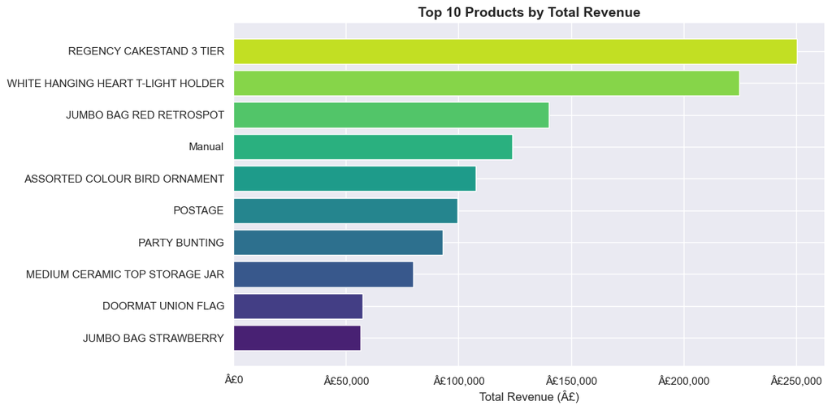

```python
# Top 10 products by revenue â€” use Description from products table where available
top_products = (
    df.dropna(subset=['Description'])
    .groupby('Description')['Revenue']
    .sum()
    .sort_values(ascending=False)
    .head(10)
)

fig, ax = plt.subplots(figsize=(12, 6))
ax.barh(top_products.index[::-1], top_products.values[::-1],
        color=sns.color_palette('viridis', 10))
ax.set_title('Top 10 Products by Total Revenue')
ax.set_xlabel('Total Revenue (Â£)')
ax.xaxis.set_major_formatter(mticker.FuncFormatter(lambda x, _: f'Â£{x:,.0f}'))
plt.tight_layout()
plt.savefig('top_products.png', dpi=150, bbox_inches='tight')
plt.show()
```

### 4.6 Orders vs. Revenue by Country (Scatter)

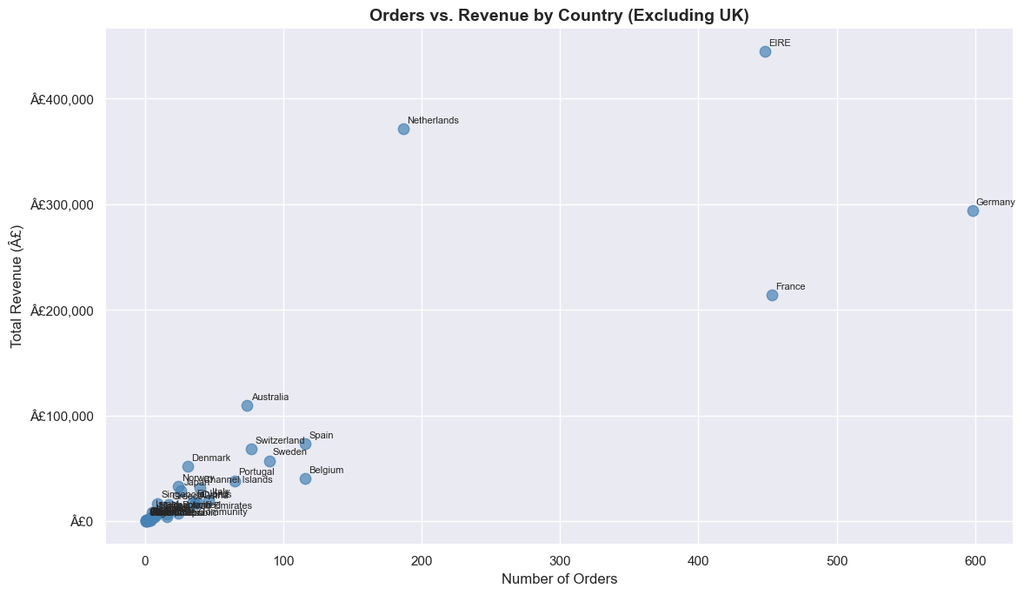

```python
# Compare order volume vs revenue per country â€” reveals high-value vs high-volume markets
country_summary = (
    df.groupby('Country')
    .agg(Total_Revenue=('Revenue', 'sum'),
         Total_Orders=('Invoice', 'nunique'))
    .reset_index()
)

# Exclude the top outlier (United Kingdom) for a cleaner view of other countries
other_countries = country_summary[country_summary['Country'] != 'United Kingdom']

fig, ax = plt.subplots(figsize=(12, 7))
scatter = ax.scatter(other_countries['Total_Orders'],
                     other_countries['Total_Revenue'],
                     s=80, alpha=0.7, color='steelblue')

# Label each point with country name
for _, row in other_countries.iterrows():
    ax.annotate(row['Country'], (row['Total_Orders'], row['Total_Revenue']),
                fontsize=8, ha='left', va='bottom', xytext=(3, 3),
                textcoords='offset points')

ax.set_title('Orders vs. Revenue by Country (Excluding UK)')
ax.set_xlabel('Number of Orders')
ax.set_ylabel('Total Revenue (Â£)')
ax.yaxis.set_major_formatter(mticker.FuncFormatter(lambda x, _: f'Â£{x:,.0f}'))
plt.tight_layout()
plt.savefig('orders_vs_revenue_by_country.png', dpi=150, bbox_inches='tight')
plt.show()
```

## 5. Key Findings Summary

```python
total_revenue    = df['Revenue'].sum()
total_orders     = df['Invoice'].nunique()
total_customers  = df['Customer_ID'].nunique()
total_products   = df['StockCode'].nunique()
top_country      = df.groupby('Country')['Revenue'].sum().idxmax()
top_category     = df.dropna(subset=['Category']).groupby('Category')['Revenue'].sum().idxmax()
date_range       = f"{df['Invoice_time'].min().strftime('%b %Y')} — {df['Invoice_time'].max().strftime('%b %Y')}"

print('=' * 50)
print('       SALES PERFORMANCE SUMMARY')
print('=' * 50)
print(f'  Date Range:        {date_range}')
print(f'  Total Revenue:     £{total_revenue:,.2f}')
print(f'  Total Orders:      {total_orders:,}')
print(f'  Unique Customers:  {total_customers:,}')
print(f'  Unique Products:   {total_products:,}')
print(f'  Top Country:       {top_country}')
print(f'  Top Category:      {top_category}')
print('=' * 50)
```

[output not shown]

## 6. Conclusions & Recommendations

### What the Data Tells Us

**Geographic concentration is a double-edged sword.**  
The United Kingdom dominates revenue to the point of being excluded from comparative scatter analysis as an outlier. While this reflects a strong home market, it represents significant dependency on a single geography. Any disruption — economic, regulatory, or logistical — carries outsized risk.

**Home goods are the revenue engine.**  
The Home category leads all others in total revenue and share. This isn't surprising for a UK-based retailer, but it suggests the product mix is well-aligned with the core customer base. Seasonal and Accessories categories show meaningful contribution as well, particularly around Q4.

**Revenue is seasonal — Q4 is critical.**  
The monthly trend consistently shows elevated revenue in the October–December window, driven by holiday purchasing. This is expected for a retailer selling home décor, gifts, and seasonal items. Planning inventory, staffing, and marketing around this cycle is essential.

**A small group of customers drives outsized revenue.**  
The top 10 customers account for a disproportionate share of total revenue. This level of concentration is common in B2B or wholesale retail models, but it signals risk — losing one high-value account has measurable impact on the bottom line.

**International markets are underpenetrated relative to their order volume.**  
Several countries in the scatter analysis show high order counts but relatively low revenue — indicating smaller average order values. These markets may represent growth opportunities if average basket size can be increased through product mix or minimum order incentives.

### Recommendations

| # | Recommendation | Rationale |
| --- | --- | --- |
| 1 | **Develop international market strategy** | Countries with high order frequency but low revenue per order are candidates for upsell campaigns or bundled product offerings |
| 2 | **Protect and grow top-10 customer relationships** | Concentrated revenue from a small customer base warrants proactive account management and loyalty incentives |
| 3 | **Build Q4 operational capacity in advance** | Seasonal peaks require inventory build-up and logistics planning starting in Q3 |
| 4 | **Invest in Home and Accessories categories** | These categories already have proven demand — deeper product variety and promotional focus would likely yield strong returns |
| 5 | **Monitor and diversify UK dependency** | Long-term resilience requires growing international revenue share, particularly in high-performing European markets |